# **DATA MINING - Projet Botanic**

- Faiçal SBAI & Alain BONDZA
- Création : 04/2023

# **DATA MINING - Projet Botanic**

- **Etudiants** : Faiçal SBAI & Alain BONDZA
- **Année de réalisation** : 2023
- **Sujet** :
- **Attrition des clients** : Identifier les clients qui sont attritionnistes en 2017 versus ceux qui sont non attritionnistes
- **Histoire et Contexte** :
- Botanic® est une chaîne de magasins fondée en France en 1995. L'enseigne propose une sélection de plantes, d'outils de jardinage, de produits bio pour le jardin et la maison, ainsi que des conseils de jardinage écologique. Elle se positionne sur la thématique du respect de l'environnement et la promotion du développement durable.
- Au travers d’un réseau de 70 magasins en France, Botanic® est le troisième groupe sur le marché de la jardinerie en France après InVivo et Truffaut.
- Comme toute entreprise, Botanic peut être confrontée à un défis de fidélisation de sa clientèle. L'attrition de ses clients peut être due à plusieurs facteurs, tels que :
  - Une Concurrence accrue à travers l'émergence de nouvelles enseignes, ou de la présence d'autres concurrents dans le secteur du jardinage et des produits bio.
  - Une évolution des préférences de ses consommateurs avec le temps, ce qui doit conduire Botanic® à s'adapter pour répondre aux nouvelles demandes du marché. Si les clients trouvent des alternatives plus attractives, ou si les produits de Botanic® ne correspondent plus à leurs besoins, cela peut entraîner une attrition des clients.
  - Un service à la clientèle médiocre, qui occasionne des problèmes récurrents, et peut entraîner une baisse de la fidélité des clients.
  - Les changements économiques dû aux fluctuations économiques, telles que les récessions ou les périodes de ralentissement économique, peuvent affecter les dépenses des consommateurs et entraîner une réduction de sa clientèle.
- **Botanic® en bref (2016-2017)** :
- **ACTIVITÉ** : jardinerie, animalerie, décoration, marché bio, bien-être.
- **CRÉATION** : 1977 (Les Serres du Salève) et 1995 (marque Botanic)
- **IMPLANTATION** : Archamps (siège social)
- **CHIFFRE D’AFFAIRES** : 364M€ (2016-2017)
- **EFFECTIFS** : 2200 salariés
- **MAGASINS (France)** : 70
- **RÉPARTITION DU CAPITAL** : les familles « opérationnelles » Blanchet et Bouchet viennent d’augmenter leur participation, les familles Verdonnet ayant vendu une grande partie de leurs parts. Les montants ne sont pas communiqués.
- **Demande de l'enseigne Botanic®** :

L’ambition de l'enseigne Botanic® est de devenir la jardinerie naturelle préférée des français en conciliant jardin et nature, croissance et responsabilité sociétale de l’entreprise. Pour cette raison, l'enseigne Botanic® souhaite : - Identifier les clients attritionnistes en 2017. - Disposer d'un modèle prédictif de l'attrition. - Obtenir des recommandations marketing de rétention des clients encore actifs mais à risque d'attrition en 2017.

- **Objectif** :
  - Expliquer (et mesurer) l'influence de facteurs sur un départ des clients à la concurrence (l'attrition des clients)
    - Prédire le risque de départ à la concurrence d'un client.
  - Prédire l'événement : Prendre des décisions pour agir sur certains facteurs :
    - retenir les clients,
    - optimiser les offres commerciales,
    - mieux cibler une campagne marketing,
    - diminuer le risque de départ à la concurrence,
    - personnaliser les actions commerciales, etc.
- **Source des données** :
  - Bases de données de l’enseigne Botanic des années 2016 et 2017.
- **Périmètre de l’étude** :
  - Le périmètre de l’étude est limitée à plusieurs régions en France pour les clients non-VIP uniquement.
  - Focus sur les clients ayant fait au moins 2 achats
- **Modélisation** : Supervisée. **Modèle** : Régression Logistique
  - La régression logistique est le modèle qui sera utilisé dans le cadre de ce projet.

# **Data Preprocessing**

## **1- Initialisation de l'environnement :**

### **Appel des librairies nécessaires**

```python
# Appel des librairies nécessaires

import pandas as pd                     # Pour manipuler les dataframes
import stats_desc as st                 # Pour les statistiques (besoin que le fichier "stats_desc.py" soit dans le même dossier que ce notebook).
import numpy as np                      # Pour faire des tableaux

import matplotlib.pyplot as plt         # Pour les graphiques
import seaborn as sns                   # Pour visualisation des données
import datetime as dt

import scipy.stats
```

## **2- Lecture du fichier en entrée :**

```python
# Création de l'environnement de travail
filepath = 'import/REF_MAGASIN.CSV'
```

### **2.1- Acquisition du dataset**

```python
# Aperçu du fichier
with open(filepath, 'r') as file:
    for line in range(10):
        print(file.readline(), end = '')
```

```
CODESOCIETE|VILLE|LIBELLEDEPARTEMENT|LIBELLEREGIONCOMMERCIALE
MET|METZ-TESSY|74|Rhône-Alpes
ALB|GILLY SUR ISERE|73|Rhône-Alpes
ALM|LES MILLES|13|Littoral
AVI|VILLENEUVE-LES-AVIGNON|30|Littoral
BEA|BEAUMONT|63|Centre-Paris
BEC|STRASBOURG|67|Alsace-Est
BLA|BLAGNAC|31|Littoral
BRE|BRETIGNY-SUR-ORGE|91|Centre-Paris
CLA|CLAPIERS|34|Littoral
```

### **2.2- Nombre de lignes du fichier**

```python
# Nombre de lignes du fichier
with open(filepath, 'r') as file:
    nblines = len(file.readlines())

print('nombre de lignes : ', nblines)
```

```
nombre de lignes :  68
```

## **3- Check sur la structure des bases**

### **3.1- Création du dataframe (Jeu de données) client et affichage des 10 premières lignes**

```python
# Création du dataframe "magasin"
print(filepath)
magasin = pd.read_csv(filepath, sep = '|')

# Affiche les 10 premières lignes du dataframe
magasin.head(10)
```

```
import/REF_MAGASIN.CSV
```

|  | CODESOCIETE | VILLE | LIBELLEDEPARTEMENT | LIBELLEREGIONCOMMERCIALE |
| --- | --- | --- | --- | --- |
| 0 | MET | METZ-TESSY | 74 | Rhône-Alpes |
| 1 | ALB | GILLY SUR ISERE | 73 | Rhône-Alpes |
| 2 | ALM | LES MILLES | 13 | Littoral |
| 3 | AVI | VILLENEUVE-LES-AVIGNON | 30 | Littoral |
| 4 | BEA | BEAUMONT | 63 | Centre-Paris |
| 5 | BEC | STRASBOURG | 67 | Alsace-Est |
| 6 | BLA | BLAGNAC | 31 | Littoral |
| 7 | BRE | BRETIGNY-SUR-ORGE | 91 | Centre-Paris |
| 8 | CLA | CLAPIERS | 34 | Littoral |
| 9 | VAL | VALENCE | 26 | Rhône-Alpes |

### **3.2- Inspection du dataframe**

#### **3.2.1- Nombre de lignes et de colonnes du dataframe**

```python
# Dimensions du dataframe : Nombre de lignes et de colonnes
magasin.shape
```

```
(67, 4)
```

#### **3.2.2- Vérification des noms de colonnes**

```python
# liste des colonnes pour vérification des noms de colonnes
magasin.columns
```

```
Index(['CODESOCIETE', 'VILLE', 'LIBELLEDEPARTEMENT',
       'LIBELLEREGIONCOMMERCIALE'],
      dtype='object')
```

#### **3.2.3- Informations sur les types de données du dataframe**

```python
# Comptage du nombre de type de variable
magasin.dtypes.value_counts()
```

```
object    3
int64     1
dtype: int64
```

#### **3.2.4- Affichage des types des variables en grapphique**

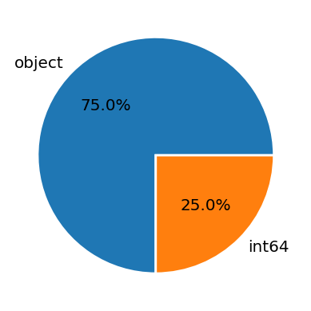

```python
# Affichage des types des variables en grapphique
magasin.dtypes.value_counts().plot.pie(autopct='%.1f%%',wedgeprops={'linewidth': 2.0, 'edgecolor': 'white'}, textprops={'size': 'x-large'})
```

#### **3.2.5- Informations sur le dataframe**

```python
# Informations sur le dataframe
magasin.info()
```

```
<class 'pandas.core.frame.DataFrame'>
RangeIndex: 67 entries, 0 to 66
Data columns (total 4 columns):
 #   Column                    Non-Null Count  Dtype
---  ------                    --------------  -----
 0   CODESOCIETE               67 non-null     object
 1   VILLE                     67 non-null     object
 2   LIBELLEDEPARTEMENT        67 non-null     int64
 3   LIBELLEREGIONCOMMERCIALE  67 non-null     object
dtypes: int64(1), object(3)
memory usage: 2.2+ KB
```

- **Note** : **valeurs manquantes** : **Aucune valeur manquante**

#### **3.2.6- Statistiques Descriptives : variables Qualitatives et Quantitatives**

#### **3.2.6.1- Affichage des premières lignes du dataframe**

```python
# Affiche des premières lignes du dataframe
magasin.head(5)
```

|  | CODESOCIETE | VILLE | LIBELLEDEPARTEMENT | LIBELLEREGIONCOMMERCIALE |
| --- | --- | --- | --- | --- |
| 0 | MET | METZ-TESSY | 74 | Rhône-Alpes |
| 1 | ALB | GILLY SUR ISERE | 73 | Rhône-Alpes |
| 2 | ALM | LES MILLES | 13 | Littoral |
| 3 | AVI | VILLENEUVE-LES-AVIGNON | 30 | Littoral |
| 4 | BEA | BEAUMONT | 63 | Centre-Paris |

#### **3.2.6.2- Statistiques Descriptives : variables Qualitatives**

```python
# Satatistiques descriptives pour vérifier les valeurs manquantes (complétude), les valeurs aberrantes...

col_quali = magasin.columns
st.get_stats_quali(magasin[col_quali])
```

|  | dtype | nunique | min | max | taux_na |
| --- | --- | --- | --- | --- | --- |
| CODESOCIETE | object | 67 | ALB | VLG | 0.0 |
| VILLE | object | 67 | ANNECY-LE-VIEUX | VIVIER AU COURT | 0.0 |
| LIBELLEDEPARTEMENT | int64 | 34 | 1 | 92 | 0.0 |
| LIBELLEREGIONCOMMERCIALE | object | 5 | Alsace-Est | Vente en ligne | 0.0 |

#### **3.2.6.3- Affichage des valeurs uniques**

```python
# Affiche les valeurs uniques des variable catégorielles
for col in ['CODESOCIETE', 'VILLE', 'LIBELLEDEPARTEMENT', 'LIBELLEREGIONCOMMERCIALE']:
    # Trie des valeurs de la variable
    magasin = magasin.sort_values(by=[col])
    print(f'{col :-<50} {magasin[col].unique()}')
```

```
CODESOCIETE--------------------------------------- ['ALB' 'ALM' 'AVI' 'BAR' 'BEA' 'BEC' 'BLA' 'BRE' 'BSN' 'CAG' 'CLA' 'CLI'
 'DIJ' 'DUM' 'ECU' 'EPN' 'EST' 'FEG' 'FRV' 'GAI' 'GAP' 'GEX' 'HAG' 'HEI'
 'IAB' 'LAB' 'MAC' 'MAN' 'MET' 'MOB' 'MOU' 'MUL' 'NEV' 'OBE' 'ORL' 'PEG'
 'PEP' 'POC' 'PON' 'PRI' 'QUE' 'RAV' 'RMA' 'SAL' 'SCH' 'SEM' 'SEY' 'SGL'
 'SJV' 'SLM' 'SMA' 'SMR' 'SNO' 'SSM' 'STE' 'STR' 'SUR' 'THO' 'VAL' 'VAR'
 'VEN' 'VIB' 'VIC' 'VIF' 'VIT' 'VIV' 'VLG']
VILLE--------------------------------------------- ['ANNECY-LE-VIEUX' 'BARCELONNETTE' 'BEAUMONT' 'BLAGNAC'
 'BRETIGNY-SUR-ORGE' 'CAGNES SUR MER' 'CESSON' 'CLAPIERS' 'CLIRON' 'DIJON'
 'ECULLY' 'EPINAL' 'FEGERSHEIM' 'FEVES' 'FRANCHEVILLE' 'GAILLARD' 'GAP'
 'GILLY SUR ISERE' 'HAGUENAU' 'HEILLECOURT' "L'ISLE-D'ABEAU"
 'LA FOUILLOUSE' 'LA RAVOIRE' 'LA SEYNE-SUR-MER' 'LABEGE CEDEX'
 'LE PONTET' 'LES MILLES' 'MACON' 'MANOSQUE' 'METZ-TESSY'
 'MONTBONNOT-SAINT-MARTIN' 'MOUANS-SARTOUX' 'MULHOUSE' 'NEVERS CEDEX'
 'OBERNAI' 'ORLEANS' 'PERPIGNAN' 'PERRIGNY' 'PONTAULT-COMBAULT' 'QUETIGNY'
 'RUEIL MALMAISON' 'SAINT-GENEST-LERPT' 'SAINT-JEAN-DE-VEDAS'
 'SAINT-MITRE-LES-REMPARTS' 'SAINT-PRIEST' 'SAINTE MAXIME' 'SALLANCHES'
 'SARGE LES LE MANS' 'SCHWEIGHOUSE-SUR-MODER' 'SEYNOD' 'SEYSSINS'
 'SISTERON' 'ST GENIS POUILLY' 'ST JULIEN EN GENEVOIS CEDEX' 'STRASBOURG'
 'SURESNES' 'THONON-LES-BAINS' 'VALENCE' 'VARENNES VAUZELLES' 'VENELLES'
 'VILLE-LA-GRAND' 'VILLECHETIF' 'VILLEFRANCHE-SUR-SAONE'
 'VILLENEUVE-LES-AVIGNON' 'VILLEURBANNE' 'VITROLLES' 'VIVIER AU COURT']
LIBELLEDEPARTEMENT-------------------------------- [ 1  4  5  6  8 10 13 21 26 30 31 34 38 42 45 54 57 58 63 66 67 68 69 71
 72 73 74 77 83 84 88 89 91 92]
LIBELLEREGIONCOMMERCIALE-------------------------- ['Alsace-Est' 'Centre-Paris' 'Littoral' 'Rhône-Alpes' 'Vente en ligne']
```

### **Rapport (1ères Observations) Checklist de base : Analyse de Forme**

- **Variable Target** :
- **Lignes et Colonnes** : 67, 4
- **Types de variables** : qualitatives : 3, quantitatives : 1
- **Analyse des valeurs manquantes** : Toutes les variables sont renseignées à 100%. **Aucune valeur manquante dans le jeu de données**.
- **Valeurs abérantes** : Dans la variable **LIBELLEREGIONCOMMERCIALE**, la modalité **Vente en ligne** n'est pas le libellé d'une région commerciale. Cette modalité sera supprimée du jeu de données.
- **Formatting des variables** : La variable **LIBELLEDEPARTEMENT** est de type **INT64** et sera convertie en **INT32**

## **4- Identification et Traitement des valeurs (manquantes, doublons, aberrantes), Formatage des variables et Filtre sur le périmètre**

### **4.1- Affichage des valeurs manquantes - Observation de tout le jeu de données dans une image** :

- **Aucune valeur manquante dans le jeu de données**.

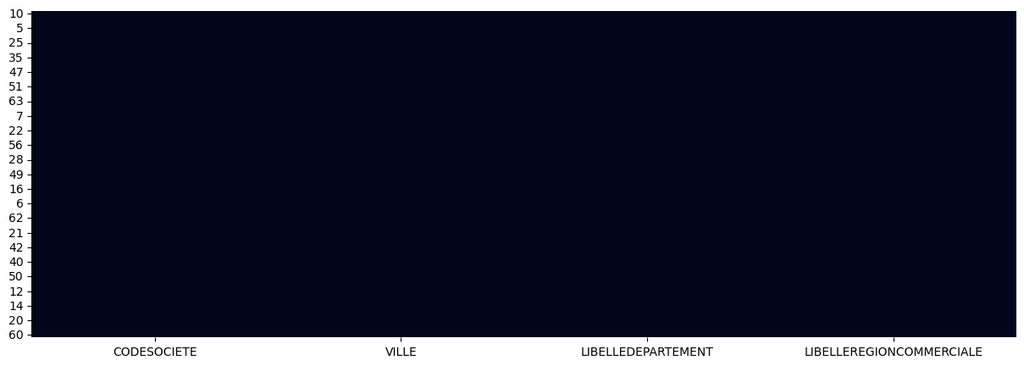

```python
plt.figure(figsize=(15,5))
sns.heatmap(magasin.isna(), cbar=False)
```

- **Note** : **Affichage des valeurs manquantes - Observation de tout le jeu de données dans une image**
  - En noir, ce sont les positions dans lesquelles il y a des valeurs.
  - En blanc, ce sont les positions dans lesquelles il y a des valeurs manquantes.
  - Notre jeu de données n'a aucune valeur manquante.

### **4.2- Mesure du pourcentage des valeurs manquantes** :

- **Aucune valeur manquante dans le jeu de données**.

```python
# Affichage en pourcentage des valeurs manquantes
(magasin.isna().sum()/magasin.shape[0]).sort_values(ascending=True)
```

```
CODESOCIETE                 0.0
VILLE                       0.0
LIBELLEDEPARTEMENT          0.0
LIBELLEREGIONCOMMERCIALE    0.0
dtype: float64
```

### **4.3- Traitement des valeurs manquantes**

- **Aucune valeur manquante dans le jeu de données à traiter**.

```python
print(magasin.isnull().sum())
```

```
CODESOCIETE                 0
VILLE                       0
LIBELLEDEPARTEMENT          0
LIBELLEREGIONCOMMERCIALE    0
dtype: int64
```

### **4.4- Traitement des doublons**

- **Aucune ligne d'enregistrement est en doublon dans le jeu de données à traiter**.
- **CODESOCIETE** (Identifiant de la table **MAGASIN**) contient 67 valeurs uniques (*voir Statistiques descriptives*), cela correpond au nombre de lignes du jeu de données (*voir Inspection du dataframe*).

```python
magasin.duplicated().sum()
```

[output not shown]

#### **Vérification** : Nombre de lignes de l'identifiant CODESOCIETE.

```python
# Satatistiques descriptives
col_quali = ['CODESOCIETE']
st.get_stats_quali(magasin[col_quali])
```

|  | dtype | nunique | min | max | taux_na |
| --- | --- | --- | --- | --- | --- |
| CODESOCIETE | object | 67 | ALB | VLG | 0.0 |

#### **Vérification** : Nombre de lignes de l'identifiant CODESOCIETE.

```python
# Satatistiques descriptives
col_quali = magasin.columns
st.get_stats_quali(magasin[col_quali])
```

|  | dtype | nunique | min | max | taux_na |
| --- | --- | --- | --- | --- | --- |
| CODESOCIETE | object | 67 | ALB | VLG | 0.0 |
| VILLE | object | 67 | ANNECY-LE-VIEUX | VIVIER AU COURT | 0.0 |
| LIBELLEDEPARTEMENT | int64 | 34 | 1 | 92 | 0.0 |
| LIBELLEREGIONCOMMERCIALE | object | 5 | Alsace-Est | Vente en ligne | 0.0 |

#### **Vérification** : Nombre de lignes et de colonnes du dataframe.

```python
# Dimensions du dataframe : Nombre de lignes et de colonnes
magasin.shape
```

```
(67, 4)
```

### **4.5- Traitement des valeurs abérantes**

- Dans la variable **LIBELLEREGIONCOMMERCIALE**, la modalité **Vente en ligne** n'est pas le libellé d'une région commerciale. Cette modalité sera supprimée du jeu de données.

#### **4.5.1- Suppression des valeurs abérantes**

#### **4.5.1.1- Affichage des valeurs uniques**

```python
# Affiche les valeurs uniques des variable catégorielles
for col in ['LIBELLEREGIONCOMMERCIALE']:
    # Trie des valeurs de la variable
    magasin = magasin.sort_values(by=[col])
    print(f'{col :-<50} {magasin[col].unique()}')
```

```
LIBELLEREGIONCOMMERCIALE-------------------------- ['Alsace-Est' 'Centre-Paris' 'Littoral' 'Rhône-Alpes' 'Vente en ligne']
```

#### **4.5.1.2- Variable LIBELLEREGIONCOMMERCIALE** : **Suppression de toutes les lignes concernant** **Vente en ligne**

- - - **Nombre d'enregistrements concernés par la modalité à retirer du jeu de données.** :

```python
# Nombre d'enregistrements concernées par la modalité à retirer du jeu de données.
count_Vente_en_ligne = magasin['LIBELLEREGIONCOMMERCIALE'].value_counts()["Vente en ligne"]
print(f'Il y a {count_Vente_en_ligne} enregistrement(s) concerné(s) par la modalité **Vente en ligne**.')
```

```
Il y a 1 enregistrement(s) concerné(s) par la modalité **Vente en ligne**.
```

```python
# Récupération de l'ensemble des enregistrements, sauf ceux qui sont concernés par la modalité à retirer du jeu de données.
magasin = magasin[magasin['LIBELLEREGIONCOMMERCIALE'] != "Vente en ligne"]
```

#### **4.5.1.3- Variable LIBELLEREGIONCOMMERCIALE** : **Vérification de l'abscence de la modalité qui a été retirée du jeu de données**

```python
# Affiche les valeurs uniques des variable catégorielles
for col in ['LIBELLEREGIONCOMMERCIALE']:
    # Trie des valeurs de la variable
    magasin = magasin.sort_values(by=[col])
    print(f'{col :-<50} {magasin[col].unique()}')
```

```
LIBELLEREGIONCOMMERCIALE-------------------------- ['Alsace-Est' 'Centre-Paris' 'Littoral' 'Rhône-Alpes']
```

#### **4.5.1.4- Informations sur le dataframe** :

- - **Les lignes concernées par la modalité qui a été supprimée ne sont plus dans le jeu de données. Cela explique la diminution des enregistrements dans le jeu de données.**

```python
# Informations sur le dataframe : Les lignes concernées par la modalité qui a été supprimée ne sont plus dans le jeu de données. Cela explique la diminution des enregistrements dans le jeu de données.
magasin.info()
```

```
<class 'pandas.core.frame.DataFrame'>
Int64Index: 66 entries, 10 to 37
Data columns (total 4 columns):
 #   Column                    Non-Null Count  Dtype
---  ------                    --------------  -----
 0   CODESOCIETE               66 non-null     object
 1   VILLE                     66 non-null     object
 2   LIBELLEDEPARTEMENT        66 non-null     int64
 3   LIBELLEREGIONCOMMERCIALE  66 non-null     object
dtypes: int64(1), object(3)
memory usage: 2.6+ KB
```

### **4.6- Traitement des valeurs Extrêmes**

- **Aucune valeur extrême**.

```python
# Traitement des outliers
import plotly.express as px
# df = px.data.tips()
fig = px.box(magasin,y="LIBELLEDEPARTEMENT", title="Gestion des outliers - LIBELLEDEPARTEMENT")
fig.show()
```

[output not shown]

### **4.7- Formatage des variables**

- La variable **LIBELLEDEPARTEMENT** est de type entier **INT64**, elle sera convertie en entier **INT32**

#### **4.7.1- Conversion du type de la variable**

```python
# Conversion de la variable en entier "int32"
magasin['LIBELLEDEPARTEMENT'] = magasin['LIBELLEDEPARTEMENT'].astype('int32')
```

#### **4.7.2- Vérification du type de la variable**

```python
# Informations sur le dataframe
magasin.info()
```

```
<class 'pandas.core.frame.DataFrame'>
Int64Index: 66 entries, 10 to 37
Data columns (total 4 columns):
 #   Column                    Non-Null Count  Dtype
---  ------                    --------------  -----
 0   CODESOCIETE               66 non-null     object
 1   VILLE                     66 non-null     object
 2   LIBELLEDEPARTEMENT        66 non-null     int32
 3   LIBELLEREGIONCOMMERCIALE  66 non-null     object
dtypes: int32(1), object(3)
memory usage: 2.3+ KB
```

## **5- Enregistrement du fichier en fichier Parquet**

```python
# Création de l'environnement de travail
filepathparquet = 'data/magasin.parquet'
```

```python
# **Sauvegarde du jeu de données dans un fichier parquet**</font>
magasin.to_parquet(path = filepathparquet,
                            engine = 'auto',
                            compression = 'gzip',
                            index = None)
```